# Kalman Filter - Dynamic Regression

```python
import numpy as np
import pandas as pd
import matplotlib.pyplot as plt
import warnings
warnings.filterwarnings('ignore')
```

One noteworthy benefit of using the Kalman filter to fi nd β is that not only do we obtain a dynamic hedge ratio between the two assets, we also simultaneously obtain what we used to call “the moving average” of the spread. This is because, as we mentioned, β includes both the slope and the intercept between y and x. The best current estimate of the intercept is used in place of the moving average of the spread. As a by-product, it also generates an estimate of the standard deviation of the forecast error of the observable variable, which we can use in place of the moving standard deviation of a Bollinger band.

### Reading Data

```python
cl = pd.read_csv('inputData_ETF.csv', header=None)
```

```python
x = cl[10].to_numpy()
y = cl[11].to_numpy()
```

Plotting Cointegrated series

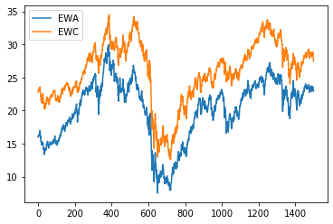

```python
plt.plot(x, label='EWA')
plt.plot(y, label='EWC')
plt.legend()
plt.show()
```

Allowing for dynamic offset

```python
x = np.append(np.expand_dims(x, axis=1), np.expand_dims(np.ones(len(x)), axis=1), axis=1)
```

### Modelling

Whatabout Vw and Ve? There is a method to estimate these variances from data called autocovariance least squares developed by Rajamani and Rawlings(2007, 2009).

But for simplicity, we will follow Montana and assume $ω = (δ/1−δ) * I$ where δ is a parameter between 0 and 1, and I is a 2 × 2 identity matrix.

If δ = 0, this means β(t) = β(t − 1), which reduces the Kalman fi lter to ordinary least square regression with a fi xed offset and slope. If δ = 1, this means the estimated β will fl uctuate wildly based on the latest observation. The optimal δ, just like the optimal lookback in a moving linear regression, can be obtained using training data. With the benefi t of hindsight, we pick δ = 0.0001. With the same hindsight, we also pick Ve = 0.001.

#### Initialization

```python
delta = 0.0001

yhat = np.full_like(y, np.nan, dtype=np.double)
e = np.full_like(y, np.nan, dtype=np.double)
Q = np.full_like(y, np.nan, dtype=np.double)

R = np.zeros((2,2))
P = np.zeros((2,2)) # R(t|t) = P(t)

beta = np.empty((len(x), 2))
beta[:] = np.nan

Vw = delta/(1-delta) * np.identity(2)
Ve = 0.001

beta[0] = 0.0
```

#### Iteration

```python
for t in range(len(y)):

    if t > 0:

        '''State Prediction'''
        beta[t] = beta[t-1]

        '''State Covariance Prediction'''
        R = P + Vw

    '''Measurement Prediction'''
    yhat[t] = x[t].dot(beta[t])

    '''Measurement Variance Prediction'''
    Q[t] = x[t] @ R @ x[t].transpose() + Ve

    '''Forecast Error'''
    e[t] = y[t] - yhat[t]

    '''Kalman Gain'''
    K = (R @ x[t].transpose()) / Q[t]

    '''State Update'''
    beta[t] += K * e[t]

    '''State Covariance Update'''
    P = R - (np.expand_dims(K, 1) @ np.expand_dims(x[t], 0) @ R)
```

#### Visualizations

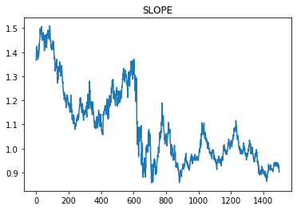

```python
plt.plot(beta[1:, 0])
plt.title('SLOPE')
plt.show()
```

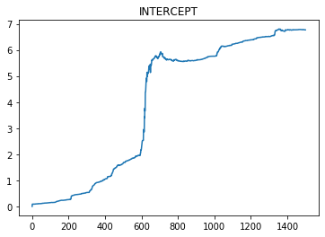

```python
plt.plot(beta[:, 1])
plt.title('INTERCEPT')
plt.show()
```

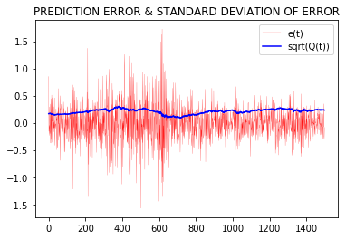

```python
plt.plot(e[2:], 'r', linewidth=0.2, label='e(t)')
plt.plot(np.sqrt(Q[2:]), 'b', label='sqrt(Q(t))')
plt.title('PREDICTION ERROR & STANDARD DEVIATION OF ERROR')
plt.legend()
plt.show()
```

### Strategy Construction

```python
y2 = np.concatenate((np.expand_dims(x[:, 0], 1), np.expand_dims(y, 1)), axis=1)
```

The measurement prediction error e(t) (previously called the forecast error for y(t) given observation at t − 1) is none other than the deviation of the spread EWC-EWA from its predicted mean value, and we will buy this spread when the deviation is very negative, and vice versa if it is very positive.

```python
longsEntry = e < -np.sqrt(Q) # a long position means we should buy EWC
longsExit = e > -np.sqrt(Q)
shortsEntry = e > np.sqrt(Q)
shortsExit = e < np.sqrt(Q)
```

```python
numUnitsLong = np.full_like(y, np.nan, dtype=np.double)
numUnitsShort = np.full_like(y, np.nan, dtype=np.double)
```

```python
numUnitsLong[0] = 0
numUnitsLong[longsEntry] = 1
numUnitsLong[longsExit] = 0

numUnitsShort[0] = 0
numUnitsShort[shortsEntry] = -1
numUnitsShort[shortsExit] = 0
```

```python
numUnits = numUnitsLong + numUnitsShort
```

#### Shares Allocation:

```
np.concatenate((-np.expand_dims(beta[:, 0], axis=1),
                np.expand_dims(np.ones(len(beta)), axis=1))
```

#### Dollar Capital Allocation:

```
np.concatenate((-np.expand_dims(beta[:, 0], axis=1),
                np.expand_dims(np.ones(len(beta)), axis=1))

                *

                y2
```

#### Dollar Capital in each ETF:

```
np.repeat(numUnits[:, np.newaxis], y2.shape[1], axis=1)

                *

np.concatenate((-np.expand_dims(beta[:, 0], axis=1),
                np.expand_dims(np.ones(len(beta)), axis=1))

                *

                y2
```

```python
positions = np.multiply(np.multiply(np.repeat(numUnits[:, np.newaxis], y2.shape[1], axis=1),
                                    np.concatenate((-np.expand_dims(beta[:, 0], axis=1),
                                                     np.expand_dims(np.ones(len(beta)), axis=1)), axis=1)),
                        y2)
```

#### Daily P&L of Strategy

```python
pnl = np.sum(np.multiply(pd.DataFrame(positions).shift(1).fillna(0).to_numpy(),
                         pd.DataFrame(y2).pct_change().fillna(0).to_numpy()),
             axis=1)
```

return is P&L divided by gross market value of portfolio

```python
ret = np.divide(pnl,
                np.sum(abs(pd.DataFrame(positions).shift(1)).to_numpy(), axis=1))
```

```python
ret = np.nan_to_num(ret, nan=0)
```

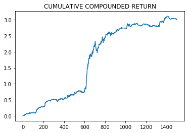

```
APR = 0.262
Sharpe = 2.362
```

```python
plt.plot(np.cumprod(ret+1)-1)
plt.title('CUMULATIVE COMPOUNDED RETURN')
plt.show()
print(f"APR = {round(np.prod(ret+1)**(252/len(ret))-1,3)}")
print(f"Sharpe = {round(np.sqrt(252) * np.mean(ret) / np.std(ret),3)}")
```